# 03-practicing-r-markdown

ymq-ymq

2020/3/26

## Abstract

Use **rmarkdown** to produce a report to consider approximation of the distribution function of $N(0, 1)$ by the Monte Carlo methods.

## Keywords

Rmarkdown, $N(0, 1)$, Monte Carlo

## Introduction

This report to consider approximation of the distribution function of $N(0, 1)$ by the Monte Carlo methods. Repeat the experiment 100 times. Draw box plots of the 100 approximation errors at each $t$ using **ggplot2** [@R-ggplot2] for each $n$. The report contain the abstract, keywords, introduction,math equations, analysis and results.

## Math Equations

In this report will consider approximation of the distribution function of $N(0, 1)$,
$$\begin{equation}
\Phi(t) = \int_{-\infty}^t \frac{1}{\sqrt{2\pi}} e^{-y^2 / 2} \dd y,
(\#eq:cdf)
\end{equation}$$
by the Monte Carlo methods:
$$\begin{equation}
\hat\Phi(t) = \frac{1}{n} \sum_{i=1}^n I(X_i \le t),
\end{equation}$$
where $X_i$’s are a random sample from $N(0, 1)$, and $I(\cdot)$ is the indicator function. Experiment with the approximation at $n \in \{10^2, 10^3, 10^4\}$ at $t \in \{0.0, 0.67, 0.84, 1.28, 1.65, 2.32, 2.58, 3.09, 3.72\}$ to form a table.

## Analysis

### Approximation of the distribution function of $N(0, 1)$ by the Monte Carlo methods

```r
t=c(0,0.67,0.84,1.28,1.65,2.32,2.58,3.09,3.72)
n=c(10^2, 10^3, 10^4)
p=matrix(0,nrow=9,ncol=3)
#a=0
for (i in 1:9)
  for(j in 1:3){
    #a=a+1
    num=rnorm(n[j],0,1)
    p[i,j]=mean(num<t[i])
    #print(a)
  }
rownames(p)<-t
colnames(p)<-n
true_value<-c(pnorm(0),pnorm(0.67),pnorm(0.84),pnorm(1.28),pnorm(1.65),
           pnorm(2.32),pnorm(2.58),pnorm(3.09),pnorm(3.72))
p<-cbind(p,true_value)
p<-round(p,digits=3)
#make figure
library(knitr)
library(magrittr)
library(kableExtra)
library(callr)
library(webshot)
kable(p, booktabs=TRUE, caption='(ref:norm)') %>%
 kable_styling(bootstrap_options = "striped",full_width = F) %>%
 column_spec(1,bold=T)#full_width=F, is or isn't full of screen
```

|  | 100 | 1000 | 10000 | true_value |
| --- | --- | --- | --- | --- |
| 0 | 0.47 | 0.514 | 0.505 | 0.500 |
| 0.67 | 0.73 | 0.740 | 0.752 | 0.749 |
| 0.84 | 0.83 | 0.813 | 0.797 | 0.800 |
| 1.28 | 0.87 | 0.889 | 0.904 | 0.900 |
| 1.65 | 0.94 | 0.953 | 0.951 | 0.951 |
| 2.32 | 0.99 | 0.987 | 0.991 | 0.990 |
| 2.58 | 1.00 | 0.996 | 0.996 | 0.995 |
| 3.09 | 1.00 | 1.000 | 0.999 | 0.999 |
| 3.72 | 1.00 | 1.000 | 1.000 | 1.000 |

### Repeat the experiment 100 times and draw box plots of the 100 approximation errors at each $t$

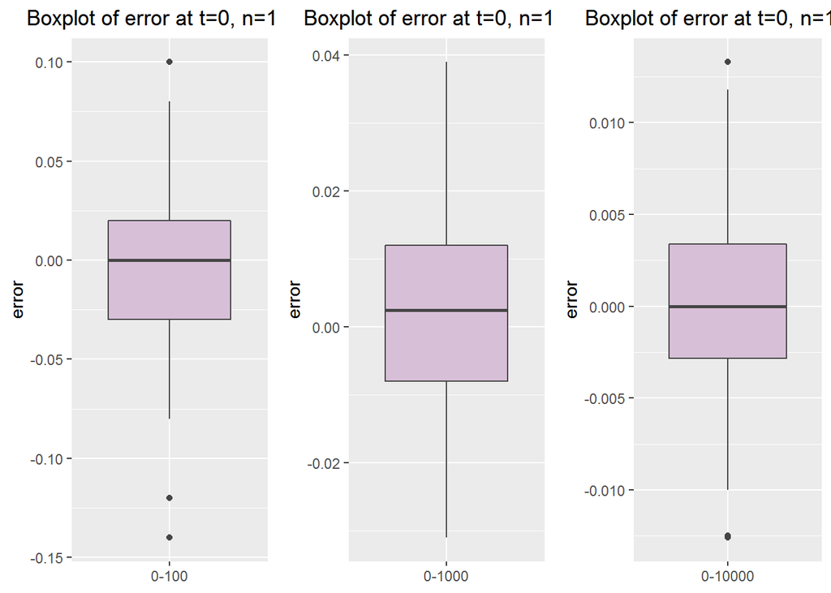

```r
#generate table
t=c(0,0.67,0.84,1.28,1.65,2.32,2.58,3.09,3.72)
n=c(10^2, 10^3, 10^4)
p=matrix(0,nrow=9,ncol=3)
a=0
for (i in 1:9)
  for(j in 1:3){
    a=a+1
    num=rnorm(n[j],0,1)
    p[i,j]=mean(num<t[i])
    print(a)
  }
rownames(p)<-t
colnames(p)<-n
pcycle=array(0,dim=c(9,3,100))
#sprouting graph
a=0
for (i in 1:9)
  for(j in 1:3)
    for (k in 1:100){
      a=a+1
      num=rnorm(n[j],0,1)
      pcycle[i,j,k]=mean(num<t[i])
      print(a)
    }
dimnames(pcycle)[[1]]<-t
dimnames(pcycle)[[2]]<-n
#Generate a dataframe
V1<-c(1:100)
plot_data<-data.frame(V1)
k=0
for (i in 1:9)
  for (j in 1:3){
    k=k+1
    print(k)
    plot_data[ ,k]<-pcycle[i,j, ]
    plot_data[ ,k]<-plot_data[ ,k]-pnorm(t[i])
  }
label<-data.frame(label1<-c("0-100"),label2<-c("0-1000"),label3<-c("0-10000"),label4<-c("0.67-100"),label5<-c("0.67-1000"),label6<-c("0.67-10000"),label7<-c("0.84-100"),label8<-c("0.84-1000"),label9<-c("0.84-10000"),label10<-c("1.28-100"),label11<-c("1.28-1000"),label12<-c("1.28-10000"),label13<-c("1.65-100"),label14<-c("1.65-1000"),label15<-c("1.65-10000"),label16<-c("2.32-100"),label17<-c("2.32-1000"),label18<-c("2.32-10000"),label19<-c("2.58-100"),label20<-c("2.58-1000"),label21<-c("2.58-10000"),label22<-c("3.09-100"),label23<-c("3.09-1000"),label24<-c("3.09-10000"),label25<-c("3.72-100"),label26<-c("3.72-1000"),label27<-c("3.72-10000"))
library(ggplot2)
library(lattice)
library(plyr)
library(Rmisc)
#t=0
p1<-ggplot(data=plot_data,aes(y=V1,x=label1))+geom_boxplot(
  fill="thistle",colour="gray27")+
  labs(title="Boxplot of error at t=0, n=10^2",y="error",
       x=NULL)+theme(plot.title=element_text(size=13,hjust=0.5))
p2<-ggplot(data=plot_data,aes(y=V2,x=label2))+geom_boxplot(fill="thistle",colour="gray27")+
  labs(title="Boxplot of error at t=0, n=10^3",y="error",x=NULL)+theme(plot.title=element_text(size=13,hjust=0.5))
p3<-ggplot(data=plot_data,aes(y=V3,x=label3))+geom_boxplot(fill="thistle",colour="gray27")+
  labs(title="Boxplot of error at t=0, n=10^4",y="error",x=NULL)+theme(plot.title=element_text(size=13,hjust=0.5))
g1<-multiplot(p1,p2,p3,cols=3)
```

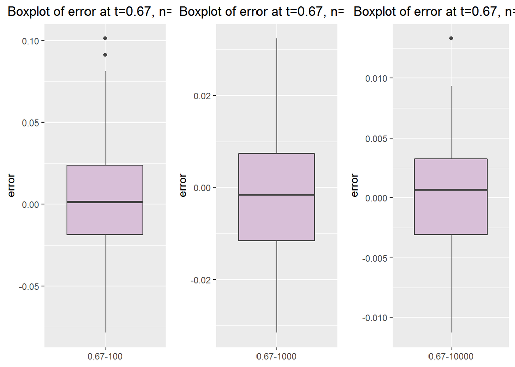

```r
#t=0.67
p4<-ggplot(data=plot_data,aes(y=V4,x=label4))+geom_boxplot(fill="thistle",colour="gray27")+
  labs(title="Boxplot of error at t=0.67, n=10^2",y="error",x=NULL)+theme(plot.title=element_text(size=13,hjust=0.5))
p5<-ggplot(data=plot_data,aes(y=V5,x=label5))+geom_boxplot(fill="thistle",colour="gray27")+
  labs(title="Boxplot of error at t=0.67, n=10^3",y="error",x=NULL)+theme(plot.title=element_text(size=13,hjust=0.5))
p6<-ggplot(data=plot_data,aes(y=V6,x=label6))+geom_boxplot(fill="thistle",colour="gray27")+
  labs(title="Boxplot of error at t=0.67, n=10^4",y="error",x=NULL)+theme(plot.title=element_text(size=13,hjust=0.5))
g2<-multiplot(p4,p5,p6,cols=3)
```

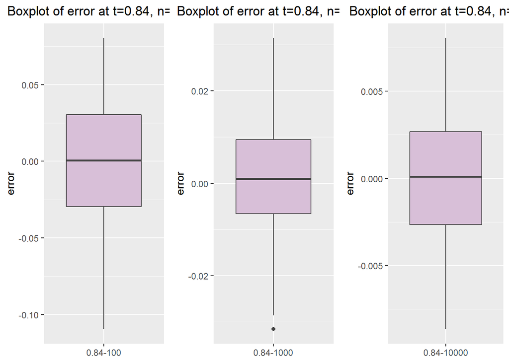

```r
#t=0.84
p7<-ggplot(data=plot_data,aes(y=V7,x=label7))+geom_boxplot(fill="thistle",colour="gray27")+
  labs(title="Boxplot of error at t=0.84, n=10^2",y="error",x=NULL)+theme(plot.title=element_text(size=13,hjust=0.5))
p8<-ggplot(data=plot_data,aes(y=V8,x=label8))+geom_boxplot(fill="thistle",colour="gray27")+
  labs(title="Boxplot of error at t=0.84, n=10^3",y="error",x=NULL)+theme(plot.title=element_text(size=13,hjust=0.5))
p9<-ggplot(data=plot_data,aes(y=V9,x=label9))+geom_boxplot(fill="thistle",colour="gray27")+
  labs(title="Boxplot of error at t=0.84, n=10^4",y="error",x=NULL)+theme(plot.title=element_text(size=13,hjust=0.5))
g3<-multiplot(p7,p8,p9,cols=3)
```

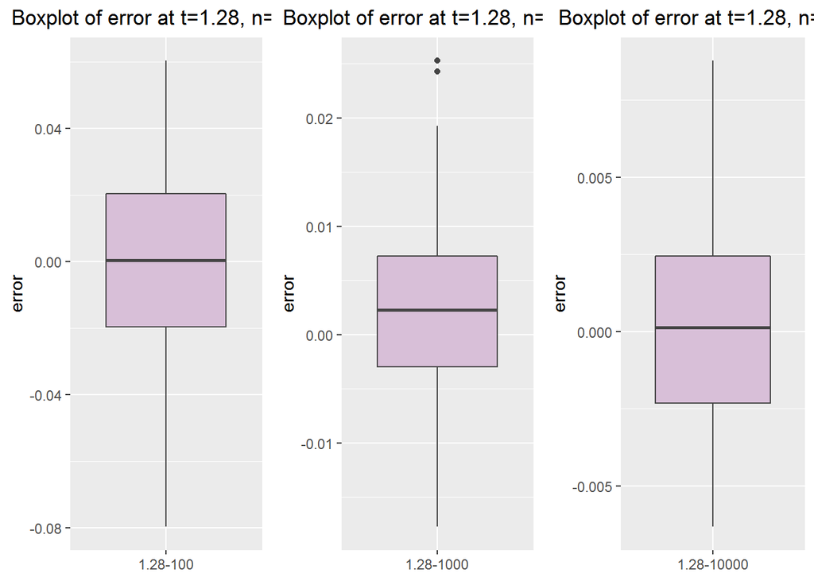

```r
#t=1.28
p10<-ggplot(data=plot_data,aes(y=V10,x=label10))+geom_boxplot(fill="thistle",colour="gray27")+
  labs(title="Boxplot of error at t=1.28, n=10^2",y="error",x=NULL)+theme(plot.title=element_text(size=13,hjust=0.5))
p11<-ggplot(data=plot_data,aes(y=V11,x=label11))+geom_boxplot(fill="thistle",colour="gray27")+
  labs(title="Boxplot of error at t=1.28, n=10^3",y="error",x=NULL)+theme(plot.title=element_text(size=13,hjust=0.5))
p12<-ggplot(data=plot_data,aes(y=V12,x=label12))+geom_boxplot(fill="thistle",colour="gray27")+
  labs(title="Boxplot of error at t=1.28, n=10^4",y="error",x=NULL)+theme(plot.title=element_text(size=13,hjust=0.5))
g4<-multiplot(p10,p11,p12,cols=3)
```

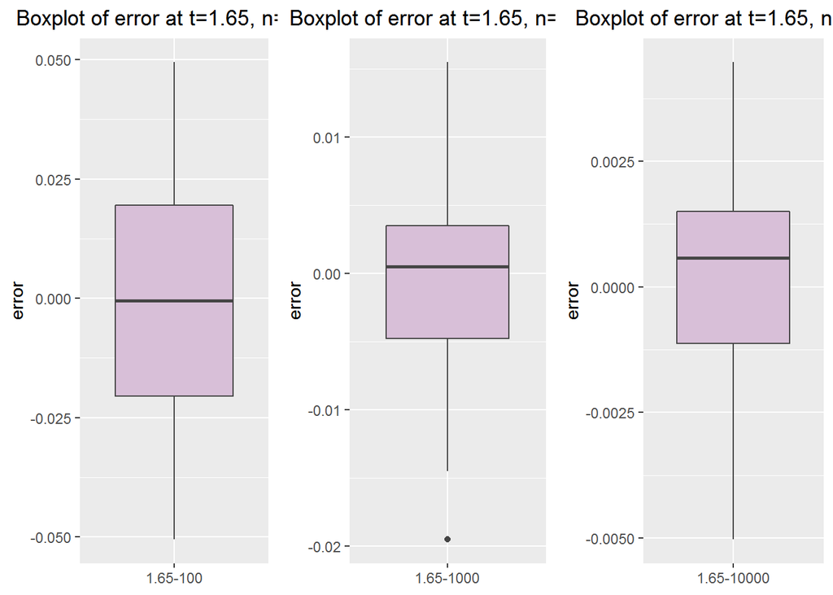

```r
#t=1.65
p13<-ggplot(data=plot_data,aes(y=V13,x=label13))+geom_boxplot(fill="thistle",colour="gray27")+
  labs(title="Boxplot of error at t=1.65, n=10^2",y="error",x=NULL)+theme(plot.title=element_text(size=13,hjust=0.5))
p14<-ggplot(data=plot_data,aes(y=V14,x=label14))+geom_boxplot(fill="thistle",colour="gray27")+
  labs(title="Boxplot of error at t=1.65, n=10^3",y="error",x=NULL)+theme(plot.title=element_text(size=13,hjust=0.5))
p15<-ggplot(data=plot_data,aes(y=V15,x=label15))+geom_boxplot(fill="thistle",colour="gray27")+
  labs(title="Boxplot of error at t=1.65, n=10^4",y="error",x=NULL)+theme(plot.title=element_text(size=13,hjust=0.5))
g5<-multiplot(p13,p14,p15,cols=3)
```

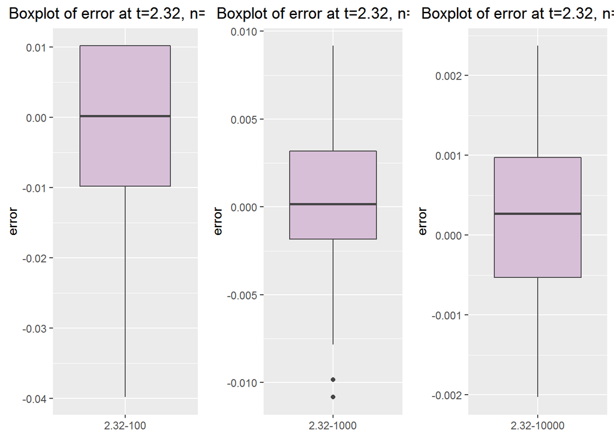

```r
#t=2.32
p16<-ggplot(data=plot_data,aes(y=V16,x=label16))+geom_boxplot(fill="thistle",colour="gray27")+
  labs(title="Boxplot of error at t=2.32, n=10^2",y="error",x=NULL)+theme(plot.title=element_text(size=13,hjust=0.5))
p17<-ggplot(data=plot_data,aes(y=V17,x=label17))+geom_boxplot(fill="thistle",colour="gray27")+
  labs(title="Boxplot of error at t=2.32, n=10^3",y="error",x=NULL)+theme(plot.title=element_text(size=13,hjust=0.5))
p18<-ggplot(data=plot_data,aes(y=V18,x=label18))+geom_boxplot(fill="thistle",colour="gray27")+
  labs(title="Boxplot of error at t=2.32, n=10^4",y="error",x=NULL)+theme(plot.title=element_text(size=13,hjust=0.5))
g6<-multiplot(p16,p17,p18,cols=3)
```

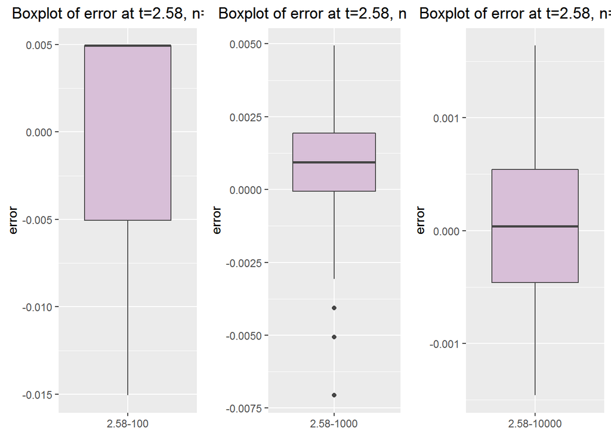

```r
#t=2.58
p19<-ggplot(data=plot_data,aes(y=V19,x=label19))+geom_boxplot(fill="thistle",colour="gray27")+
  labs(title="Boxplot of error at t=2.58, n=10^2",y="error",x=NULL)+theme(plot.title=element_text(size=13,hjust=0.5))
p20<-ggplot(data=plot_data,aes(y=V20,x=label20))+geom_boxplot(fill="thistle",colour="gray27")+
  labs(title="Boxplot of error at t=2.58, n=10^3",y="error",x=NULL)+theme(plot.title=element_text(size=13,hjust=0.5))
p21<-ggplot(data=plot_data,aes(y=V21,x=label21))+geom_boxplot(fill="thistle",colour="gray27")+
  labs(title="Boxplot of error at t=2.58, n=10^4",y="error",x=NULL)+theme(plot.title=element_text(size=13,hjust=0.5))
g7<-multiplot(p19,p20,p21,cols=3)
```

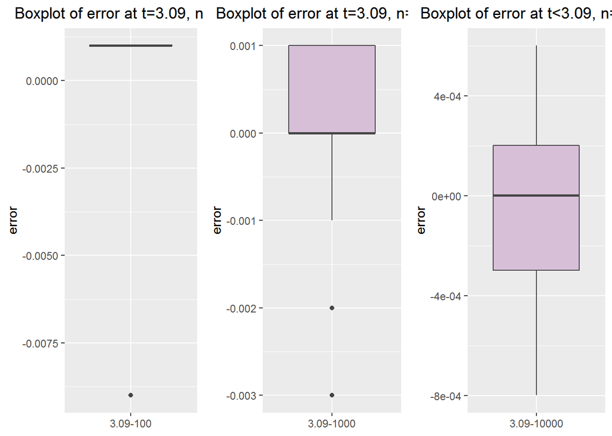

```r
#t=3.09
p22<-ggplot(data=plot_data,aes(y=V22,x=label22))+geom_boxplot(fill="thistle",colour="gray27")+
  labs(title="Boxplot of error at t=3.09, n=10^2",y="error",x=NULL)+theme(plot.title=element_text(size=13,hjust=0.5))
p23<-ggplot(data=plot_data,aes(y=V23,x=label23))+geom_boxplot(fill="thistle",colour="gray27")+
  labs(title="Boxplot of error at t=3.09, n=10^3",y="error",x=NULL)+theme(plot.title=element_text(size=13,hjust=0.5))
p24<-ggplot(data=plot_data,aes(y=V24,x=label24))+geom_boxplot(fill="thistle",colour="gray27")+
  labs(title="Boxplot of error at t<3.09, n=10^4",y="error",x=NULL)+theme(plot.title=element_text(size=13,hjust=0.5))
g8<-multiplot(p22,p23,p24,cols=3)
```

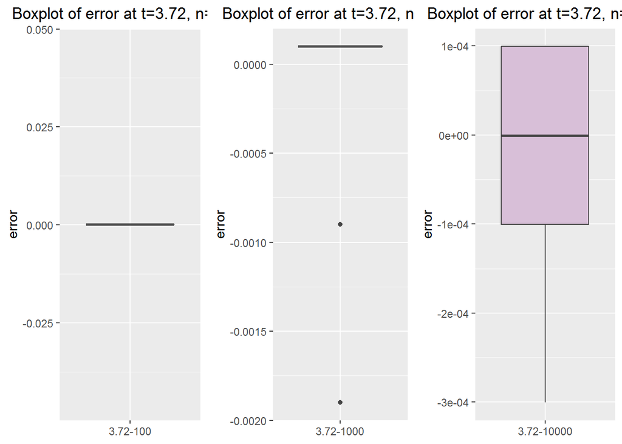

```r
#t=3.72
p25<-ggplot(data=plot_data,aes(y=V25,x=label25))+geom_boxplot(fill="thistle",colour="gray27")+
  labs(title="Boxplot of error at t=3.72, n=10^2",y="error",x=NULL)+theme(plot.title=element_text(size=13,hjust=0.5))
p26<-ggplot(data=plot_data,aes(y=V26,x=label26))+geom_boxplot(fill="thistle",colour="gray27")+
  labs(title="Boxplot of error at t=3.72, n=10^3",y="error",x=NULL)+theme(plot.title=element_text(size=13,hjust=0.5))
p27<-ggplot(data=plot_data,aes(y=V27,x=label27))+geom_boxplot(fill="thistle",colour="gray27")+
  labs(title="Boxplot of error at t=3.72, n=10^4",y="error",x=NULL)+theme(plot.title=element_text(size=13,hjust=0.5))
g9<-multiplot(p25,p26,p27,cols=3)
```

## Results

Through the above analysis, we could get the approximation of the distribution function of $N(0, 1)$ by the Monte Carlo methods and draw box plots of approximation errors at each $t$ by repeating the experiment 100 times.